## Genetic structure and dispersal of the mountainous star coral along the Caribbean basin

## Create a conda environment and activate it

```
conda create -n Orbicella ddocent
conda activate Orbicella
```

## Let´s make a working directory and change to it

```
mkdir Orbicella_Raw
cd Orbicella_Raw
```

## There are 2 GBS libraries, each one with 95 individuals and a “Blank” sample, for a total of 190 individuals and 2 Blank samples. Let`s make a directory for each sequencing library

```
mkdir A_H5FYWBGXY
mkdir B_HCFMGBGXY
```

## Now we`re going to symlink all the raw sequncing files to the its correspondent directory in our working directory

```
ln -s /RAID_STORAGE2/Shared_Data/Prada_Data/Orbicella/Orbicella_Cornell_raw/CORNELL_DATA_CORAL_ADAPTATION/H5FYWBGXY_1_fastq.gz ./A_H5FYWBGXY

ln -s /RAID_STORAGE2/Shared_Data/Prada_Data/Orbicella/Orbicella_Cornell_raw/CORNELL_DATA_CORAL_ADAPTATION/HCFMGBGXY_1_fastq.gz ./B_HCFMGBGXY
```

## The sample and barcode files for each library are already included in each directory

```
cat A_H5FYWBGXY/barcodes_H5FYWBGXY_rename
cat B_HCFMGBGXY/barcodes_HCFMGBGXY_rename
```

## Now we need to turn them into a list of barcodes for each library.

```
cut -f2 A_H5FYWBGXY/barcodes_H5FYWBGXY_rename > barcodes_H5FYWBGXY
cut -f2 B_HCFMGBGXY/barcodes_HCFMGBGXY_rename > barcodes_HCFMGBGXY
```

## We are now going to check read quality of each library using FASTQC program

```
fastqc /RAID_STORAGE2/mgomez/Orbicella_Raw/A_H5FYWBGXY/*.fq.gz
fastqc /RAID_STORAGE2/mgomez/Orbicella_Raw/B_HCFMGBGXY/*fq.gz
```

## we are now going to aggregate the results from FASTQC analyses across all samples into a single report.

## First install the program MultiQC

```
conda install multiqc
Proceed ([y]/n)? y

multiqc /RAID_STORAGE2/mgomez/Orbicella_Raw/A_H5FYWBGXY/
multiqc /RAID_STORAGE2/mgomez/Orbicella_Raw/B_HCFMGBGXY/
```

## Now we copy the multiqc reports for each library to the class repository

```
cp /RAID_STORAGE2/mgomez/Orbicella_Raw/A_H5FYWBGXY/multiqc_report.html /home/mgomez/repos/BIO_594_2019/Final_Assignment/Matias_Final_Project/Orbicella_Files/MultiQC_Reports/A_H5FYWBGXY_RAW_multiqc_report.html

 cp /RAID_STORAGE2/mgomez/Orbicella_Raw/B_HCFMGBGXY/multiqc_report.html /home/mgomez/repos/BIO_594_2019/Final_Assignment/Matias_Final_Project/Orbicella_Files/MultiQC_Reports/B_HCFMGBGXY_RAW_multiqc_report.html
```

## We are now goin to estimate number of reads in our data following the script ReferenceOpt.sh from dDocent (https://github.com/jpuritz/dDocent/blob/master/scripts/ReferenceOpt.sh)

## Create a new folder called RefOpt

## Place a subset of individuals of your total data set

## Less than 5 individuals per region or locality

## This only needs to capture the total variability present in your data set

## Include all .fq.gz files for each individual

## Run ReferenceOpt.sh

## Visualize data in kopt.data

## Plot values for each k1,k2 combination across similarity thresholds

## Pick a similarity threshold at the point of inflection on the curve ##Here’s some R code to quickly plot this for you (Taken from http://www.ddocent.com/quick/):

[output not shown]

## Visualize data in kopt.data. Plot values for each k1,k2 combination across similarity thresholds. Pick a similarity threshold at the point of inflection on the curve * Here’s some R code to quickly plot this for you:

```
library(ggplot2)

data.table <- read.table("/RAID_STORAGE2/mgomez/Orbicella_Raw/Libraries_A_B/RefOpt/kopt.data", header = FALSE, col.names= c("k1","k2","Similarity", "Contigs"))

data.table$K1K2 <- paste(data.table$k1, data.table$k2, sep=",")

df=data.frame(data.table)
df$K1K2 <- as.factor(df$K1K2)

p <- ggplot(df, aes(x=Similarity, y=Contigs, group=K1K2)) + scale_x_continuous(breaks=seq(0.8,0.98,0.01)) + geom_line(aes(colour = K1K2))
p
```

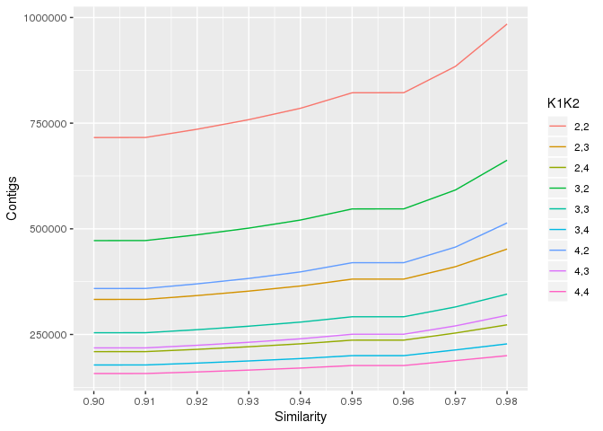

## We can now go ahead and demultiplex the data. This means we are going to separate individuals by barcode.For this task we are going to use process_radtags from the Stacks package (http://creskolab.uoregon.edu/stacks/) process_radtags takes fastq or fastq.gz files as input along with a file that lists barcodes.

```
process_radtags -f A_H5FYWBGXY/H5FYWBGXY_1_fastq.gz -b barcodes_H5FYWBGXY -e apeKI -r -i gzfastq

process_radtags -f B_HCFMGBGXY/HCFMGBGXY_1_fastq.gz -b barcodes_HCFMGBGXY -e apeKI -r -i gzfastq
```

## The option -e specifies the 5’ restriction site, -i states the format of the input sequences.The -r option tells the program to fix cut sites and barcodes that have up to 1-2 mutations in them. This can be changed with the –barcode_dist flag.

# Now copy the demultiplexed files from dir A_H5FYWBGXY and B_HCFMGBGXY to a new dir and change to it

```
mkdir Libraries_A_B
cp A_H5FYWBGXY/*fq.gz .
cp B_HCFMGBGXY/*fq.gz .
cd Libraries_A_B
```

## Download O.faveolata genome

```
wget ftp://ftp.ncbi.nlm.nih.gov/sra/wgs_aux/MZ/GG/MZGG01/MZGG01.1.fsa_nt.gz
```

## Unzip O.faveolata genome

```
gunzip MZGG01.1.fsa_nt.gz
```

## rename O.faveolata genome

```
mv MZGG01.1.fsa_nt.gz reference.fasta
```

# Running dDocent on demultiplex files in Libraries_A_B

```
dDocent
dDocent 2.7.7

Contact jpuritz@uri.edu with any problems


Checking for required software

All required software is installed!

dDocent run started Sat Apr 27 13:28:20 EDT 2019

190 individuals are detected. Is this correct? Enter yes or no and press [ENTER]
yes

Proceeding with 190 individuals
dDocent detects 80 processors available on this system.
Please enter the maximum number of processors to use for this analysis.
20
dDocent detects 503 gigabytes of maximum memory available on this system.
Please enter the maximum memory to use for this analysis in gigabytes
For example, to limit dDocent to ten gigabytes, enter 10
This option does not work with all distributions of Linux.  If runs are hanging at variant calling, enter 0
Then press [ENTER]
0
Do you want to quality trim your reads?
Type yes or no and press [ENTER]?
yes

Do you want to perform an assembly?
Type yes or no and press [ENTER].
no

Do you want to map reads?  Type yes or no and press [ENTER]
yes

Please enter your email address.  dDocent will email you when it is finished running.
Don`t worry; dDocent has no financial need to sell your email address to spammers.
matias_gomez@uri.edu.co

At this point, all configuration information has been entered and dDocent may take several hours to run.
It is recommended that you move this script to a background operation and disable terminal input and output.
All data and logfiles will still be recorded.
To do this:
Press control and Z simultaneously
Type 'bg' without the quotes and press enter
Type 'disown -h' again without the quotes and press enter

Now sit back, relax, and wait for your analysis to finish

(Orbicella) [mgomez@KITT Libraries_A_B]$^Z
[1]+  Stopped                 dDocent

(Orbicella) [mgomez@KITT Libraries_A_B]$ bg
[1]+ dDocent &
(Orbicella) [mgomez@KITT Libraries_A_B]$ disown -h
```

### Now we are going to check read quality of each fastq file after filtering in dDcocent :dDocent takes a minimalistic approach to quality filtering, using the program Trimmomatic. Low quality bases (below quality score of 20) are removed from the beginning and end of reads, and an additional sliding 5bp window that will trim bases when the average quality score drops below 10. Additionally, Illumina adapters are detected and removed.Files that have a .R1.fq and .R2.fq are the filtered FASTQ files.

```
fastqc /RAID_STORAGE2/mgomez/Orbicella_Raw/Libraries_A_B/*.R1.fq.gz
```

## we are now going to aggregate the results from FASTQC analyses across all samples into a single report and move it the class repository.

```
multiqc multiqc /RAID_STORAGE2/mgomez/Orbicella_Raw/Libraries_A_B/
cp /RAID_STORAGE2/mgomez/Orbicella_Raw/Libraries_A_B/multiqc_report.html /home/mgomez/repos/BIO_594_2019/Final_Assignment/Matias_Final_Project/Orbicella_Files/MultiQC_Reports/All_Trimmed_Samples_multiqc_report.html
```

## SNP filtering (http://www.ddocent.com/filtering/)

## First, let´s create a working dir and change to it, then copy the raw VCF file generetaed by dDocent to start the SNP filtering

```
mkdir SNP_Filtering
cd SNP_Filtering
cp /RAID_STORAGE2/mgomez/Orbicella_Raw/Libraries_A_B/TotalRawSNPs.vcf .
```

## we are going to use the program VCFtools (http://vcftools.sourceforge.net) to filter our vcf file. To make this file more manageable, let’s start by applying three step filter. We are going to only keep variants that have been successfully genotyped in 50% of individuals, a minimum quality score of 30, and a minor allele count of 3

```
vcftools --gzvcf TotalRawSNPs.vcf --max-missing 0.5 --mac 3 --minQ 30 --recode --recode-INFO-all --out raw.g5mac3
After filtering, kept 190 out of 190 Individuals
Outputting VCF file...
After filtering, kept 286741 out of a possible 1909564 Sites
Run Time = 225.00 seconds
```

## We now have a filtered VCF called raw.g5mac3.recode.vcf. There is also a logfile generated called raw.g5mac3.log The next filter we will apply is a minimum depth for a genotype call and a minimum mean depth

## This command will recode genotypes that have less than 3 reads.

```
vcftools --vcf raw.g5mac3.recode.vcf --minDP 3 --recode --recode-INFO-all --out raw.g5mac3dp3

After filtering, kept 190 out of 190 Individuals
Outputting VCF file...
After filtering, kept 286741 out of a possible 286741 Sites
Run Time = 172.00 seconds
```

## the genotype is based on three reads AND prior information from all reads from all individuals

## Let`s run a script to help evaluate the potential errors.

```
curl -L -O https://github.com/jpuritz/dDocent/raw/master/scripts/ErrorCount.sh
chmod +x ErrorCount.sh
./ErrorCount.sh raw.g5mac3dp3.recode.vcf

This script counts the number of potential genotyping errors due to low read depth
It report a low range, based on a 50% binomial probability of observing the second allele in a heterozygote and a high range based on a 25% probability.
Potential genotyping errors from genotypes from only 1 read range from 0 to 0.0
Potential genotyping errors from genotypes from only 2 reads range from 0 to 0.0
Potential genotyping errors from genotypes from only 3 reads range from 213354 to 716870.28
Potential genotyping errors from genotypes from only 4 reads range from 82347 to 416348.328
Potential genotyping errors from genotypes from only 5 reads range from 33933 to 257351
190 number of individuals and 286741 equals 54480790 total genotypes
Total genotypes not counting missing data 33687181
Total potential error rate is between 0.00978514646269 and 0.0412788950194
SCORCHED EARTH SCENARIO
WHAT IF ALL LOW DEPTH HOMOZYGOTE GENOTYPES ARE ERRORS?????
The total SCORCHED EARTH error rate is 0.12201273238.
```

## The next step is to get rid of individuals that did not sequence well. We can do this by assessing individual levels of missing data.

```
vcftools --vcf raw.g5mac3dp3.recode.vcf --missing-indv
After filtering, kept 190 out of 190 Individuals
Outputting Individual Missingness
After filtering, kept 286741 out of a possible 286741 Sites
Run Time = 11.00 seconds
```

## This will create an output called out.imiss. Let’s examine it.

```
cat out.imiss

INDV    N_DATA  N_GENOTYPES_FILTERED    N_MISS  F_MISS
CU_101  286741  0       6157    0.0214723
CU_102  286741  0       5901    0.0205795
CU_103  286741  0       7084    0.0247052
CU_104  286741  0       8867    0.0309234
CU_105  286741  0       157410  0.548962
CU_106  286741  0       286720  0.999927
CU_10   286741  0       282069  0.983707
CU_11   286741  0       252201  0.879543
CU_12   286741  0       220290  0.768254
CU_13   286741  0       123839  0.431885
CU_14   286741  0       286646  0.999669
CU_15   286741  0       5549    0.019352
CU_16   286741  0       13933   0.0485909
CU_17   286741  0       5546    0.0193415
CU_1    286741  0       206909  0.721588
CU_20   286741  0       286546  0.99932
CU_22   286741  0       271762  0.947761
CU_23   286741  0       6769    0.0236067
CU_24   286741  0       286333  0.998577
CU_25   286741  0       5905    0.0205935
CU_26   286741  0       7578    0.026428
CU_27   286741  0       51670   0.180197
CU_28   286741  0       286663  0.999728
CU_2    286741  0       196792  0.686306
CU_30   286741  0       5633    0.0196449
CU_31   286741  0       256709  0.895264
CU_32   286741  0       259326  0.904391
CU_33   286741  0       137164  0.478355
CU_34   286741  0       234483  0.817752
CU_35   286741  0       224239  0.782026
CU_37   286741  0       7219    0.025176
CU_38   286741  0       72091   0.251415
CU_39   286741  0       49068   0.171123
CU_3    286741  0       167516  0.584207
CU_40   286741  0       284575  0.992446
CU_41   286741  0       11514   0.0401547
CU_42   286741  0       286735  0.999979
```

[output cut: 138 more lines]

```
PR_85   286741  0       7583    0.0264455
PR_86   286741  0       45535   0.158802
PR_87   286741  0       19400   0.0676569
PR_88   286741  0       133245  0.464688
PR_89   286741  0       5679    0.0198053
PR_90   286741  0       24200   0.0843967
PR_91   286741  0       104761  0.365351
PR_92   286741  0       268004  0.934655
PR_93   286741  0       280432  0.977998
PR_94   286741  0       6974    0.0243216
PR_95   286741  0       11982   0.0417868
PR_96   286741  0       285062  0.994145
PR_97   286741  0       143123  0.499137
PR_98   286741  0       276924  0.965764
PR_99   286741  0       285445  0.99548
```

## We can see that some individuals have as high as 99% missing data. We definitely want to filter those out. Let’s take a look at a histogram

```
mawk '!/IN/' out.imiss | cut -f5 > totalmissing
gnuplot << \EOF
set terminal dumb size 120, 30
set autoscale
unset label
set title "Histogram of % missing data per individual"
set ylabel "Number of Occurrences"
set xlabel "% of missing data"
#set yr [0:100000]
binwidth=0.01
bin(x,width)=width*floor(x/width) + binwidth/2.0
plot 'totalmissing' using (bin($1,binwidth)):(1.0) smooth freq with boxes
pause -1
EOF

                                  Histogram of % missing data per individual

  40 ++--------+---------+---------+---------+---------+----------+---------+---------+---------+---------+--------++
     +         +         +         +         +         +       'totalmissing' using (bin($1,binwidth)):(1.0) ****** +
     |                                                                                                   **         |
  35 ++                                                                                                  **        ++
     |                                                                                                   **         |
     |                                                                                                   **         |
  30 ++                                                                                                  **        ++
     |                                                                                                   **         |
     |                                                                                                   **         |
  25 ++**                                                                                                **        ++
     | **                                                                                                **         |
  20 ++**                                                                                                **        ++
     | **                                                                                                **         |
     | **                                                                                                **         |
  15 ++**                                                                                                **        ++
     | **                                                                                                **         |
     |***                                                                                                **         |
  10 +***                                                                                                **        ++
     |*****                                                                                              **         |
     |*****                                                                                              **         |
   5 +*****                                                                                             ***        ++
     |**********                                          ****           **          ***                ****        |
     +****** * ********************************************  *************************+*********************        +
   0 +******************************************************************************************************-------++
     0        0.1       0.2       0.3       0.4       0.5        0.6       0.7       0.8       0.9        1        1.1
                                                    % of missing data
```

## There a lot of individuals with missing more than 50 % missing data. Now we need to create a list of individuals with more than 50% missing data.

```
mawk '$5 > 0.5' out.imiss | cut -f1 > lowDP.indv
```

## Now that we have a list of individuals to remove, we can feed that directly into VCFtools for filtering.

```
vcftools --vcf raw.g5mac3dp3.recode.vcf --remove lowDP.indv --recode --recode-INFO-all --out raw.g5mac3dplm

Excluding individuals in 'exclude' list
After filtering, kept 95 out of 190 Individuals
Outputting VCF file...
After filtering, kept 286741 out of a possible 286741 Sites
Run Time = 103.00 seconds
```

## Now that we have removed poor coverage individuals, we can restrict the data to variants called in a high percentage of individuals and filter by mean depth of genotypes

```
vcftools --vcf raw.g5mac3dplm.recode.vcf --max-missing 0.95 --maf 0.05 --recode --recode-INFO-all --out DP3g95maf05 --min-meanDP 20

After filtering, kept 95 out of 95 Individuals
Outputting VCF file...
After filtering, kept 37241 out of a possible 286741 Sites
Run Time = 22.00 seconds
```

## Since we have multiple localities being sampled we are also going to want to filter by a population specific call rate.

## First, we need to create file that has two tab separated columns. First with the sample name, second with population assignment.

```
vcf-query -l DP3g95maf05.recode.vcf > DP3g95maf05.indv
cut -d "_" -f1 DP3g95maf05.indv > DP3g95maf05.indv.pop
paste DP3g95maf05.indv DP3g95maf05.indv.pop  > popmap
```

## Then we use a script made By Jon Puritz (dDcocent) for multi-locality studies. It’s called pop_missing_filter.sh Executing it with no parameters will give you the usage.

```
curl -L -O https://github.com/jpuritz/dDocent/raw/master/scripts/pop_missing_filter.sh
chmod +x pop_missing_filter.sh
./pop_missing_filter.sh
```

## Let´s run the script

```
pop_missing_filter.sh DP3g95maf05.recode.vcf popmap 0.95 3 DP3g95p5maf05

After filtering, kept 95 out of 95 Individuals
Outputting VCF file...
After filtering, kept 37241 out of a possible 37241 Sites
Run Time = 13.00 seconds
```

## From this point forward, the filtering steps assume that the vcf file was generated by FreeBayes

## FreeBayes outputs a lot of information about a locus in the VCF file, using this information and the properties of RADseq, we add some sophisticated filters to the data. Let’s take a look at the header of our VCF file and take a quick look at all the information.

```
mawk '/#/' DP3g95p5maf05.recode.vcf

##fileformat=VCFv4.2
##fileDate=20190427
##source=freeBayes v1.2.0
##reference=reference.fasta
##contig=<ID=MZGG01001932.1,length=338892>
##phasing=none
##INFO=<ID=NS,Number=1,Type=Integer,Description="Number of samples with data">
##INFO=<ID=DP,Number=1,Type=Integer,Description="Total read depth at the locus">
##INFO=<ID=DPB,Number=1,Type=Float,Description="Total read depth per bp at the locus; bases in reads overlapping / bases in haplotype">
##INFO=<ID=AC,Number=A,Type=Integer,Description="Total number of alternate alleles in calledgenotypes">
##INFO=<ID=AN,Number=1,Type=Integer,Description="Total number of alleles in called genotypes">
##INFO=<ID=AF,Number=A,Type=Float,Description="Estimated allele frequency in the range (0,1]">
##INFO=<ID=RO,Number=1,Type=Integer,Description="Count of full observations of the referencehaplotype.">
##INFO=<ID=AO,Number=A,Type=Integer,Description="Count of full observations of this alternate haplotype.">
##INFO=<ID=PRO,Number=1,Type=Float,Description="Reference allele observation count, with partial observations recorded fractionally">
##INFO=<ID=PAO,Number=A,Type=Float,Description="Alternate allele observations, with partial observations recorded fractionally">
##INFO=<ID=QR,Number=1,Type=Integer,Description="Reference allele quality sum in phred">
##INFO=<ID=QA,Number=A,Type=Integer,Description="Alternate allele quality sum in phred">
##INFO=<ID=PQR,Number=1,Type=Float,Description="Reference allele quality sum in phred for partial observations">
##INFO=<ID=PQA,Number=A,Type=Float,Description="Alternate allele quality sum in phred for partial observations">
##INFO=<ID=SRF,Number=1,Type=Integer,Description="Number of reference observations on the forward strand">
##INFO=<ID=SRR,Number=1,Type=Integer,Description="Number of reference observations on the reverse strand">
##INFO=<ID=SAF,Number=A,Type=Integer,Description="Number of alternate observations on the forward strand">
##INFO=<ID=SAR,Number=A,Type=Integer,Description="Number of alternate observations on the reverse strand">
##INFO=<ID=SRP,Number=1,Type=Float,Description="Strand balance probability for the referenceallele: Phred-scaled upper-bounds estimate of the probability of observing the deviation between SRF and SRR given E(SRF/SRR) ~ 0.5, derived using Hoeffding's inequality">
##INFO=<ID=SAP,Number=A,Type=Float,Description="Strand balance probability for the alternateallele: Phred-scaled upper-bounds estimate of the probability of observing the deviation between SAF and SAR given E(SAF/SAR) ~ 0.5, derived using Hoeffding's inequality">
##INFO=<ID=AB,Number=A,Type=Float,Description="Allele balance at heterozygous sites: a number between 0 and 1 representing the ratio of reads showing the reference allele to all reads, considering only reads from individuals called as heterozygous">
##INFO=<ID=ABP,Number=A,Type=Float,Description="Allele balance probability at heterozygous sites: Phred-scaled upper-bounds estimate of the probability of observing the deviation between ABR and ABA given E(ABR/ABA) ~ 0.5, derived using Hoeffding's inequality">
##INFO=<ID=RUN,Number=A,Type=Integer,Description="Run length: the number of consecutive repeats of the alternate allele in the reference genome">
##INFO=<ID=RPP,Number=A,Type=Float,Description="Read Placement Probability: Phred-scaled upper-bounds estimate of the probability of observing the deviation between RPL and RPR given E(RPL/RPR) ~ 0.5, derived using Hoeffding's inequality">
##INFO=<ID=RPPR,Number=1,Type=Float,Description="Read Placement Probability for reference observations: Phred-scaled upper-bounds estimate of the probability of observing the deviation between RPL and RPR given E(RPL/RPR) ~ 0.5, derived using Hoeffding's inequality">
##INFO=<ID=RPL,Number=A,Type=Float,Description="Reads Placed Left: number of reads supporting the alternate balanced to the left (5') of the alternate allele">
##INFO=<ID=RPR,Number=A,Type=Float,Description="Reads Placed Right: number of reads supporting the alternate balanced to the right (3') of the alternate allele">
##INFO=<ID=EPP,Number=A,Type=Float,Description="End Placement Probability: Phred-scaled upper-bounds estimate of the probability of observing the deviation between EL and ER given E(EL/ER) ~ 0.5, derived using Hoeffding's inequality">
##INFO=<ID=EPPR,Number=1,Type=Float,Description="End Placement Probability for reference observations: Phred-scaled upper-bounds estimate of the probability of observing the deviation between EL and ER given E(EL/ER) ~ 0.5, derived using Hoeffding's inequality">
##INFO=<ID=DPRA,Number=A,Type=Float,Description="Alternate allele depth ratio.  Ratio between depth in samples with each called alternate allele and those without.">
##INFO=<ID=ODDS,Number=1,Type=Float,Description="The log odds ratio of the best genotype combination to the second-best.">
##INFO=<ID=GTI,Number=1,Type=Integer,Description="Number of genotyping iterations required to reach convergence or bailout.">
```

[output cut: 8 more lines]

```
##INFO=<ID=PAIREDR,Number=1,Type=Float,Description="Proportion of observed reference alleleswhich are supported by properly paired read fragments">
##INFO=<ID=MIN_DP,Number=1,Type=Integer,Description="Minimum depth in gVCF output block.">
##INFO=<ID=END,Number=1,Type=Integer,Description="Last position (inclusive) in gVCF output record.">
##INFO=<ID=technology.Illumina,Number=A,Type=Float,Description="Fraction of observations supporting the alternate observed in reads from Illumina">
##FORMAT=<ID=GT,Number=1,Type=String,Description="Genotype">
##FORMAT=<ID=GQ,Number=1,Type=Float,Description="Genotype Quality, the Phred-scaled marginal(or unconditional) probability of the called genotype">
##FORMAT=<ID=GL,Number=G,Type=Float,Description="Genotype Likelihood, log10-scaled likelihoods of the data given the called genotype for each possible genotype generated from the reference and alternate alleles given the sample ploidy">
##FORMAT=<ID=DP,Number=1,Type=Integer,Description="Read Depth">
##FORMAT=<ID=AD,Number=R,Type=Integer,Description="Number of observation for each allele">
##FORMAT=<ID=RO,Number=1,Type=Integer,Description="Reference allele observation count">
##FORMAT=<ID=QR,Number=1,Type=Integer,Description="Sum of quality of the reference observations">
##FORMAT=<ID=AO,Number=A,Type=Integer,Description="Alternate allele observation count">
##FORMAT=<ID=QA,Number=A,Type=Integer,Description="Sum of quality of the alternate observations">
##FORMAT=<ID=MIN_DP,Number=1,Type=Integer,Description="Minimum depth in gVCF output block.">
#CHROM  POS     ID      REF     ALT     QUAL    FILTER  INFO    FORMAT  CU_101  CU_102  CU_103       CU_104  CU_13   CU_15   CU_16   CU_17   CU_23   CU_25   CU_26   CU_27   CU_30   CU_3CU_37    CU_38   CU_39   CU_41   CU_43   CU_44   CU_47   CU_48   CU_51   CU_53   CU_54   CU_5CU_59    CU_5    CU_60…
```

## Let’s use our first filter

```
vcffilter -s -f "AB > 0.25 & AB < 0.75 | AB < 0.01" DP3g95p5maf05.recode.vcf > DP3g95p5maf05.fil1.vcf
```

## vcffilter works with simple conditional statements, so this filters out loci with an allele balance below 0.25 and above 0.75. However, it does include those that are close to zero. The last condition is to catch loci that are fixed variants (all individuals are homozygous for one of the two variants). The -s tells the filter to apply to sites, not just alleles To see how many loci are now in the VCF file, you could feed it into VCFtools or you can just use a simple mawk statement

```
mawk '!/#/' DP3g95p5maf05.recode.vcf | wc -l
37241

mawk '!/#/' DP3g95p5maf05.fil1.vcf | wc -l
30956
```

## The next filter we will apply filters out sites that have reads from both strands. For GWAS and even RNAseq, this can be a good thing. Unless you are using super small genomic fragment or really long reads (MiSeq). A SNP should be covered only by forward or only reverse reads.

```
vcffilter -f "SAF / SAR > 100 & SRF / SRR > 100 | SAR / SAF > 100 & SRR / SRF > 100" -s DP3g95p5maf05.fil1.vcf > DP3g95p5maf05.fil2.vcf
```

## The filter is based on proportions, so that a few extraneous reads won’t remove an entire locus. In plain english, it’s keeping loci that have over 100 times more forward alternate reads than reverse alternate reads and 100 times more forward reference reads than reverse reference reads along with the reciprocal.

```
mawk '!/#/' DP3g95p5maf05.fil2.vcf | wc -l
12079
```

## The next filter looks at the ratio of mapping qualities between reference and alternate alleles

```
vcffilter -f "MQM / MQMR > 0.9 & MQM / MQMR < 1.05" DP3g95p5maf05.fil2.vcf > DP3g95p5maf05.fil3.vcf
```

## The rationale here is that, again, because RADseq loci and alleles all should start from the same genomic location there should not be large discrepancy between the mapping qualities of two alleles.

```
mawk '!/#/' DP3g95p5maf05.fil3.vcf | wc -l
8946
```

## Yet another filter that can be applied is whether or not their is a discrepancy in the properly paired status of for reads supporting reference or alternate alleles.

```
vcffilter -f "PAIRED > 0.05 & PAIREDR > 0.05 & PAIREDR / PAIRED < 1.75 & PAIREDR / PAIRED > 0.25 | PAIRED < 0.05 & PAIREDR < 0.05" -s DP3g95p5maf05.fil3.vcf > DP3g95p5maf05.fil4.vcf

mawk '!/#/' DP3g95p5maf05.fil4.vcf | wc -l
8946
```

## The next filter we will apply is to look at the ration of locus quality score to depth Heng Li found some interesting results about how quality score and locus depth are related to each other in real and spurious variant calls In short, with whole genome samples, it was found that high coverage can lead to inflated locus quality scores. Heng proposed that for read depths greater than the mean depth plus 2-3 times the square root of mean depth that the quality score will be twice as large as the depth in real variants and below that value for false variants. implement two filters based on this idea. the first is removing any locus that has a quality score below 1/4 of the depth (dDocent).

```
vcffilter -f "QUAL / DP > 0.25" DP3g95p5maf05.fil4.vcf > DP3g95p5maf05.fil5.vcf
```

## The second is more complicated. The first step is to create a list of the depth of each locus

```
cut -f8 DP3g95p5maf05.fil5.vcf | grep -oe "DP=[0-9]*" | sed -s 's/DP=//g' > DP3g95p5maf05.fil5.DEPTH
```

## The second step is to create a list of quality scores.

```
mawk '!/#/' DP3g95p5maf05.fil5.vcf | cut -f1,2,6 > DP3g95p5maf05.fil5.vcf.loci.qual
```

## Next step is to calculate the mean depth

```
mawk '{ sum += $1; n++ } END { if (n > 0) print sum / n; }' DP3g95p5maf05.fil5.DEPTH
4385.9
```

## Now the the mean plus 3X the square of the mean

[output not shown]

## Next we paste the depth and quality files together and find the loci above the cutoff that do not have quality scores 2 times the depth

```
paste DP3g95p5maf05.fil5.vcf.loci.qual DP3g95p5maf05.fil5.DEPTH | mawk -v x=4584.68 '$4 > x' | mawk '$3 < 2 * $4' > DP3g95p5maf05.fil5.lowQDloci
```

## Now we can remove those sites and recalculate the depth across loci with VCFtools

```
vcftools --vcf DP3g95p5maf05.fil5.vcf --site-depth --exclude-positions DP3g95p5maf05.fil5.lowQDloci --out DP3g95p5maf05.fil5

After filtering, kept 95 out of 95 Individuals
Outputting Depth for Each Site
After filtering, kept 6591 out of a possible 8853 Sites
Run Time = 0.00 seconds
```

## Now let’s take VCFtools output and cut it to only the depth scores

```
cut -f3 DP3g95p5maf05.fil5.ldepth > DP3g95p5maf05.fil5.site.depth
```

## Now let’s calculate the average depth by dividing the above file by the number of individuals 95

```
mawk '!/D/' DP3g95p5maf05.fil5.site.depth | mawk -v x=95 '{print $1/x}' > meandepthpersite
```

## Let’s plot the data as a histogram

```
gnuplot << \EOF
set terminal dumb size 120, 30
set autoscale
set xrange [10:150]
unset label
set title "Histogram of mean depth per site"
set ylabel "Number of Occurrences"
set xlabel "Mean Depth"
binwidth=1
bin(x,width)=width*floor(x/width) + binwidth/2.0
set xtics 5
plot 'meandepthpersite' using (bin($1,binwidth)):(1.0) smooth freq with boxes
pause -1
EOF

    Histogram of mean depth per site

  300 ++--+---+---+---+---+---+---+--+---+---+---+---+---+---+---+---+---+---+---+---+---+--+---+---+---+---+---+--++
      +   +   +   +   +  **   +   +  +   +   +   +   +   + 'meandepthpersite' using (bin($1,binwidth)):(1.0)+****** +
      |                  ****                                                                                       |
      |                ******                                                                                       |
  250 ++               ******                                                                                      ++
      |                *******                                                                                      |
      |                ********                                                                                     |
      |                ********                                                                                     |
  200 ++               ***********                                                                                 ++
      |              **************                                                                                 |
      |              ****************                                                                               |
  150 ++            *****************                                                                              ++
      |            ******************                                                                               |
      |            *******************                                                                              |
      |            *******************                                                                              |
  100 ++           ***********************                                                                         ++
      |          *************************                                                                          |
      |          *************************                                                                          |
      |          *****************************                                                                      |
   50 ++        *******************************                                                                    ++
      |        *************************************                                                                |
      |       ********************************************                                                          |
      +   +   ****************************************************** **  + ****  +  **   +  +   +   +   +   +   +   +
    0 ++--+---*******************************************************************************************************
      10  15  20  25  30  35  40  45 50  55  60  65  70  75  80  85  90  95 100 105 110 115120 125 130 135 140 145 150
                                                        Mean Depth
```

### Loci that have high mean depth are indicative of either paralogs or multicopy loci. Either way we want to remove them. Here, I’d remove all loci above a mean depth of 102.5. Now we can combine both filters to produce another VCF file

```
vcftools --vcf  DP3g95p5maf05.fil5.vcf --recode-INFO-all --out DP3g95p5maf05.FIL --max-meanDP 102.5 --exclude-positions DP3g95p5maf05.fil5.lowQDloci --recode

Outputting VCF file...
After filtering, kept 6438 out of a possible 8853 Sites
Run Time = 2.00 seconds
```

### The next filter to apply is HWE. Heng Li also found that HWE is another excellent filter to remove erroneous variant calls. We don’t want to apply it across the board, since population structure will create departures from HWE as well. We need to apply this by population. I’ve included a perl script written by Chris Hollenbeck, one of the PhD student’s in my current lab that will do this for us (dDocent).

```
curl -L -O https://github.com/jpuritz/dDocent/raw/master/scripts/filter_hwe_by_pop.pl
chmod +x filter_hwe_by_pop.pl
```

## Let’s filter our SNPs by population specific HWE First, we need to convert our variant calls to SNPs To do this we will use another command from vcflib called vcfallelicprimatives

```
vcfallelicprimitives DP3g95p5maf05.FIL.recode.vcf --keep-info --keep-geno > DP3g95p5maf05.prim.vcf
```

## This will decompose complex variant calls into phased SNP and INDEL genotypes and keep the INFO flags for loci and genotypes. Next, we can feed this VCF file into VCFtools to remove indels.

```
vcftools --vcf DP3g95p5maf05.prim.vcf --remove-indels --recode --recode-INFO-all --out SNP.DP3g95p5maf05
Outputting VCF file...
After filtering, kept 6776 out of a possible 7029 Sites
Run Time = 3.00 seconds
```

## We now have 6776 SNP calls in our new VCF. Now, let’s apply the HWE filter

```
./filter_hwe_by_pop.pl -v SNP.DP3g95p5maf05.recode.vcf -p popmap -o SNP.DP3g95p5maf05.HWE -h 0.01

Processing population: CU (40 inds)
Processing population: PAN2014 (2 inds)
Processing population: PR (53 inds)
Outputting results of HWE test for filtered loci to 'filtered.hwe'
Kept 5092 of a possible 6776 loci (filtered 1684 loci)
```

## Let`s copy the filtered vcf for outlier loci detection

```
cp /RAID_STORAGE2/mgomez/Orbicella_Raw/Libraries_A_B/SNP_Filtering/SNP.DP3g95p5maf05.HWE.recode.vcf .
```

## Converting from VCF to other outputs

## Copy a PGDspider configuration file and file to map individuals to population

```
cp /home/BIO594/DATA/Week7/example/BSsnp.spid .
cp /RAID_STORAGE2/mgomez/Orbicella_Raw/Libraries_A_B/SNP_Filtering/popmap .
```

## Now, run PGDspider

```
java -jar /usr/local/bin/PGDSpider2-cli.jar -inputfile SNP.DP3g95p5maf05.HWE.recode.vcf -outputfile SNP.DP3g95p5maf05.HWE_BayesScan -spid BSsnp.spid
```

## Outlier Detection

## Run BayeScan

```
BayeScan2.1_linux64bits SNP.DP3g95p5maf05.HWE_BayesScan -threads 20 -nbp 30 -thin 20
```

## The fact that BayesCan is not running could be related to having only 2 individuals in one populations. This small number of individuals is not enough to etimate allele frequencies. So, I`m going to take out those two individuals from the last vcf file and rerun BayeScan.

## We first make a file with the individuals to want to remove:PAN2014_235 and PAN2014_240

```
nano Remove_PAN

PAN2014_235
PAN2014_240
```

## We now use vcf tools to remove the individuals from the vcf file

[output not shown]

## We need to make a new file with the populations. We overwrite the last popmap file that contained the PAN2014 population with two individual

```
vcf-query -l SNP.DP3g95p5maf05.HWE_CU_PR.recode.vcf > SNP.DP3g95p5maf05.HWE_CU_PR.indv
cut -d "_" -f1 SNP.DP3g95p5maf05.HWE_CU_PR.indv > SNP.DP3g95p5maf05.HWE_CU_PR.pop
paste SNP.DP3g95p5maf05.HWE_CU_PR.indv SNP.DP3g95p5maf05.HWE_CU_PR.pop  > popmap.txt
```

## Now, run PGDspider

```
java -jar /usr/local/bin/PGDSpider2-cli.jar -inputfile SNP.DP3g95p5maf05.HWE_CU_PR.recode.vcf -outputfile SNP.DP3g95p5maf05.HWE_CU_PR_BayesScan -spid BSsnp.spid

WARN  15:39:26 - PGDSpider configuration file not found! Loading default configuration.
initialize convert process...
read input file...
read input file done.
write output file...
write output file done.
```

## Outlier Detection

## Run BayeScan

## Here, I will actually need to find the problem to be able to run BayeScan to filter potential loci under selection.

[output not shown]

## Mow I am going to try a different way to convert the file to bayescan format

## You need to add headers to the table popmap.txt before you uploaded to R: edit the table in R by clicking on the table and add the headers (Sample Pop) space by tab:

```
popmap.txt<-read.table("~/repos/BIO_594_2019/Final_Assignment/Matias_Final_Project/Orbicella_Files/popmap.txt", header=TRUE)
popmap.txt

##    Sample Pop
## 1  CU_101  CU
## 2  CU_102  CU
## 3  CU_103  CU
## 4  CU_104  CU
## 5   CU_13  CU
## 6   CU_15  CU
## 7   CU_16  CU
## 8   CU_17  CU
## 9   CU_23  CU
## 10  CU_25  CU
## 11  CU_26  CU
```

[output cut: 82 more lines]

## Load the last vcf file to R using vcfR

```
library(vcfR)

##
##    *****       ***   vcfR   ***       *****
##      browseVignettes('vcfR') # Documentation
##      citation('vcfR') # Citation
##    *****       *****      *****       *****

SNP.DP3g95p5maf05.HWE_CU_PR.recode.vcf<- read.vcfR("SNP.DP3g95p5maf05.HWE_CU_PR.recode.vcf")

## Scanning file to determine attributes.
## File attributes:
##   meta lines: 65
##   header_line: 66
##   variant count: 5092
##   column count: 102
##
Meta line 65 read in.
## All meta lines processed.
## gt matrix initialized.
## Character matrix gt created.
##   Character matrix gt rows: 5092
##   Character matrix gt cols: 102
##   skip: 0
##   nrows: 5092
##   row_num: 0
##
Processed variant 1000
Processed variant 2000
Processed variant 3000
Processed variant 4000
Processed variant 5000
Processed variant: 5092
## All variants processed

SNP.DP3g95p5maf05.HWE_CU_PR.recode.vcf

## ***** Object of Class vcfR *****
## 93 samples
## 525 CHROMs
## 5,092 variants
## Object size: 31.7 Mb
## 0 percent missing data
## *****        *****         *****

SNP.DP3g95p5maf05.HWE_CU_PR.recode.genind <- vcfR2genind(SNP.DP3g95p5maf05.HWE_CU_PR.recode.vcf)
pop(SNP.DP3g95p5maf05.HWE_CU_PR.recode.genind) <- popmap.txt$Pop
indNames(SNP.DP3g95p5maf05.HWE_CU_PR.recode.genind)<-popmap.txt$Sample
indNames(SNP.DP3g95p5maf05.HWE_CU_PR.recode.genind)
SNP.DP3g95p5maf05.HWE_CU_PR.recode.genind_ID<-popmap.txt$Sample
SNP.DP3g95p5maf05.HWE_CU_PR.recode.genind
SNP.DP3g95p5maf05.HWE_CU_PR.recode.hierfstat <- genind2hierfstat(SNP.DP3g95p5maf05.HWE_CU_PR.recode.genind)
SNP.DP3g95p5maf05.HWE_CU_PR.recode.hierfstat

write.bayescan( dat = SNP.DP3g95p5maf05.HWE_CU_PR.recode.hierfstat, diploid =  TRUE, fn = "SNP.DP3g95p5maf05.HWE_CU_PR_BayesScan")
```

## Try to run Bayescan again

```
BayeScan2.1_linux64bits -snp SNP.DP3g95p5maf05.HWE_CU_PR_BayesScan -o SNP.DP3g95p5maf05.HWE_CU_PR_BayesScan.Output  -threads 20 -nbp 30 -thin 20
Using 20 threads (80 cpu detected on this machine)
```

## This time Bayescan did run without errors

## Copy this script to visualise and analyse Bayescan output

```
cp /RAID_STORAGE2/mgomez/Orbicella_Raw/Libraries_compiled/SNP_Filtering/plot_R.r .

source("plot_R.r")
BayeScan_Results<-plot_bayescan("SNP.DP3g95p5maf05.HWE_CU_PR_BayesScan.Output_fst.txt",FDR=0.05)
```

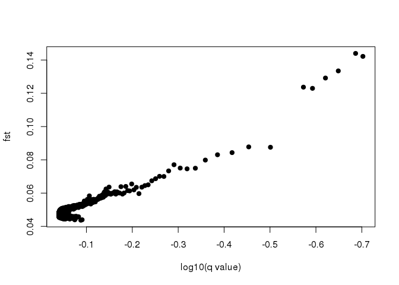

```
BayeScan_Results$outliers

## integer(0)

BayeScan_Results$nb_outliers

## [1] 0

BayeScan_Results_sel=read.table("SNP.DP3g95p5maf05.HWE_CU_PR_BayesScan.Output.sel",colClasses="numeric")
parameter="Fst1"
plot(density(BayeScan_Results_sel[[parameter]]),xlab=parameter,main=paste(parameter,"posterior distribution"))
```

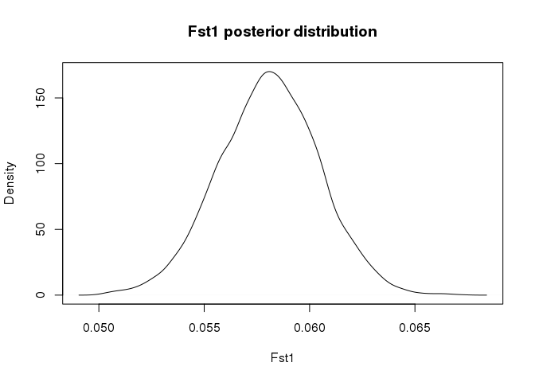

```
parameter="logL"
plot(density(BayeScan_Results_sel[[parameter]]),xlab=parameter,main=paste(parameter,"posterior distribution"))
```

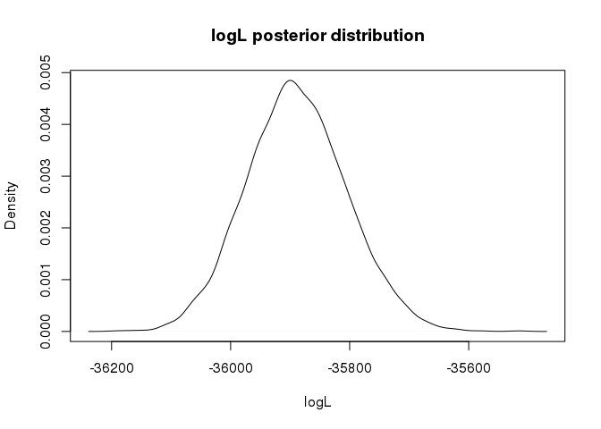

```
BayeScan_Results_Fst=read.table("SNP.DP3g95p5maf05.HWE_CU_PR_BayesScan.Output_fst.txt",colClasses="numeric")
parameter="alpha"

plot(density(BayeScan_Results_Fst[[parameter]]),xlab=parameter,main=paste(parameter,"posterior distribution"))
```

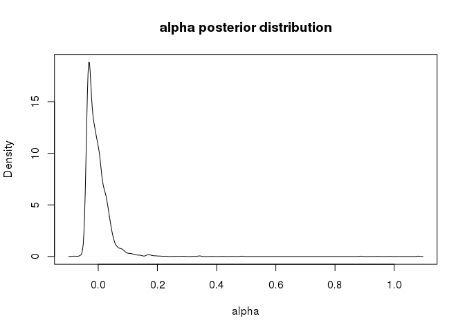

## if you have the package “boa” installed, you can very easily obtain Highest Probability

## Density Interval (HPDI) for your parameter of interest (example for the 95% interval):

## > boa.hpd(mydata $$\[parameter$$ ],0.05)

```
#install.packages("boa")
library(boa)
parameter="Fst1"
boa.hpd(BayeScan_Results_sel[[parameter]],0.05)

## Lower Bound Upper Bound
##  0.05334956  0.06271723
```

## Since we did not find any outlier loci with Bayescan, we do not need to exclude any loci from this dataset of SNPs

## Outlier detection with PCAdapt on R

## we need to limit SNPs to only those with two alleles:

```
vcftools --vcf SNP.DP3g95p5maf05.HWE.recode.vcf --min-alleles 2 --max-alleles 2 --recode --recode-INFO-all --out SNP.DP3g95p5maf05.HWE_2A

Outputting VCF file...
After filtering, kept 5030 out of a possible 5092 Sites
Run Time = 6.00 seconds
```

VCFtools - 0.1.17 (C) Adam Auton and Anthony Marcketta 2009

Parameters as interpreted: –vcf SNP.DP3g95p5maf05.HWE.recode.vcf –recode-INFO-all –max-alleles 2 –out SNP.DP3g95p5maf05.HWE_2A –recode

```
library(pcadapt)
```

## Following the tutorial available on (https://cran.r-project.org/web/packages/pcadapt/vignettes/pcadapt.html):

## The pcadapt function performs two successive tasks. First, PCA is performed on the centered and scaled genotype matrix. The second stage consists in computing test statistics and p-values based on the correlations between SNPs and the first K principal components (PCs). To run the function pcadapt, the user should specify the output returned by the function read.pcadapt and the number K of principal components to compute.

## To choose K, principal component analysis should first be performed with a large enough number of principal components (e.g. K=20).

```
filename <- read.pcadapt("SNP.DP3g95p5maf05.HWE_2A.recode.vcf", type = "vcf",allele.sep =c("/", "|") )

## 1517 variant(s) have been discarded as they are not SNPs.
## Summary:
##
##  - input file:               SNP.DP3g95p5maf05.HWE_2A.recode.vcf
##  - output file:              /tmp/RtmpS8OLPs/filef336020f632.pcadapt
##
##  - number of individuals detected:   95
##  - number of loci detected:      5030
##
## 3513 lines detected.
## 95 columns detected.

x <- pcadapt(input = filename, K=20)
```

## Since PCAdapt discarded 1517 variants beacuse they were not SNPs, I’m going to check out the allele frequency of all my SNPs to make sure the are not fixed alleles that might be being discarded by PCAdapt

## We first make a file with the frequencies of each allele

[output not shown]

## We then use the next next command line to see if there are any fixed alleles (1.0)

```
cut -f5 SNP.DP3g95p5maf05.HWE_2A.recode.vcf.frq | grep 1
```

## There does not seem to be any fixed allele so this is not the cause of the problem. Because we do not know what the variants taken out are we cannot really filter the vcf file for the identified outlier loci. I`m going to continue here running PCAdapt fot the exercise sake.

## In the future I will need to find what the problem is and why those variants are being discarded.

## I`m going to try a different way to convert the file to vcf and the outlier detection

```
library(pcadapt)
 vcf2pcadapt("SNP.DP3g95p5maf05.HWE_2A.recode.vcf", output = "SNP.DP3g95p5maf05.HWE_2A.recode.vcf.pcadapt", allele.sep = c("/", "|"))

## 5 variant(s) have been discarded as they are not SNPs.
## Summary:
##
##  - input file:               SNP.DP3g95p5maf05.HWE_2A.recode.vcf
##  - output file:              SNP.DP3g95p5maf05.HWE_2A.recode.vcf.pcadapt
##
##  - number of individuals detected:   95
##  - number of loci detected:      5030

##    [1] 0 0 0 0 0 0 0 0 0 0 0 0 0 0 0 0 0 0 0 0 0 0 0 0 0 0 0 0 0 0 0 0 0 0
##   [35] 0 0 0 0 0 0 0 0 0 0 0 0 0 0 0 0 0 0 0 0 0 0 0 0 0 0 0 0 0 0 0 0 0 0
##   [69] 0 0 0 0 0 0 0 0 0 0 0 0 0 0 0 0 0 0 0 0 0 0 0 0 0 0 0 0 0 0 0 0 0 0
```

[output cut: 145 more lines]

## This time only five variants were discarded. I still need to find out why after all the above filters there are 5 loci not deemed as SNPs.

## Make the pcadapt file “readable”

```
filename <- read.pcadapt("SNP.DP3g95p5maf05.HWE_2A.recode.vcf.pcadapt", type = "pcadapt")

## 5025 lines detected.
## 95 columns detected.

## The bed file already exists. Returning..
```

## The ‘scree plot’ displays in decreasing order the percentage of variance explained by each PC. Up to a constant, it corresponds to the eigenvalues in decreasing order. The ideal pattern in a scree plot is a steep curve followed by a bend and a straight line. The eigenvalues that correspond to random variation lie on a straight line whereas the ones that correspond to population structure lie on a steep curve. We recommend to keep PCs that correspond to eigenvalues to the left of the straight line (Cattell’s rule). In the provided example, K = 2 is the optimal choice for K. The plot function displays a scree plot:

```
x <- pcadapt(input = filename, K=20)
plot(x, option= "screeplot")
```

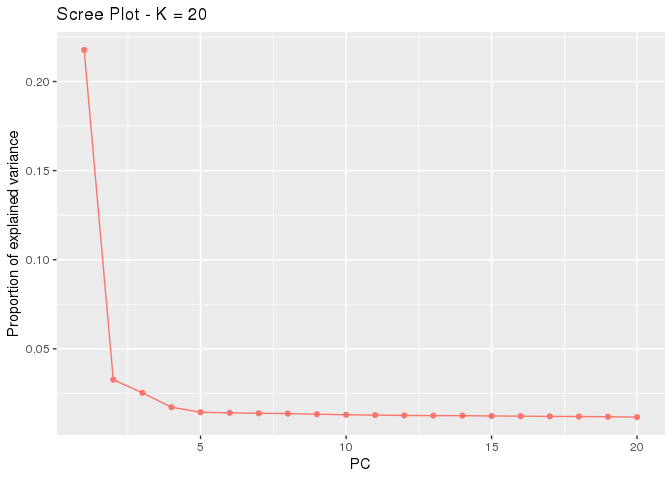

## Counting individuals in each population

```
grep CU popmap | wc -l
grep PAN2014 popmap | wc -l
grep PR popmap | wc -l

## 40
## 2
## 53
```

## When population labels are known, individuals of the same populations can be displayed with the same color using the pop argument, which should contain the list of indices of the populations of origin.

```
poplist.names <- c(rep("CU",40), rep("PAN2014",2),rep("PR",53))
plot(x, option= "scores", pop=poplist.names)
```

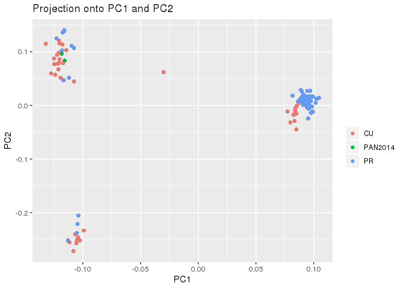

```
plot(x, option = "scores", i = 3, j = 4, pop = poplist.names)
```

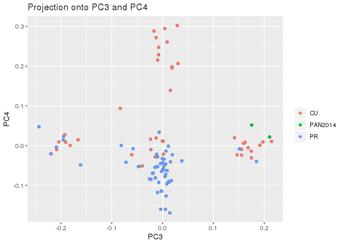

## A Manhattan plot displays −log10 of the p-values.

```
plot(x, option = "manhattan")
```

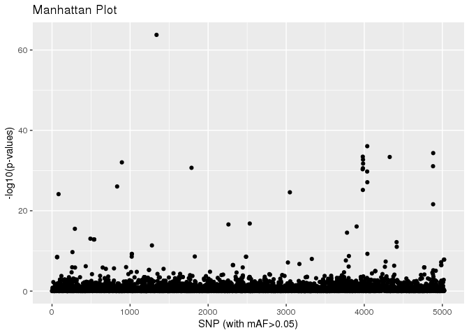

```
plot(x, option = "qqplot", threshold =0.05)
```

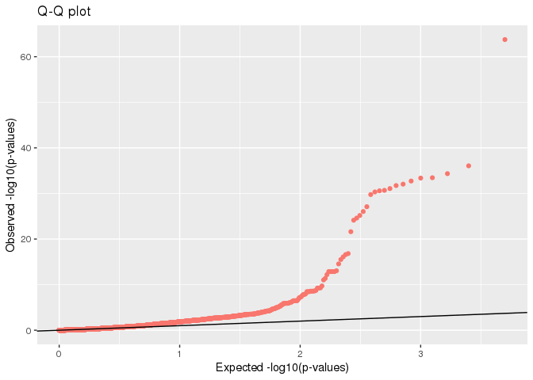

```
plot(x, option = "stat.distribution")

## Warning: Removed 19 rows containing non-finite values (stat_bin).
```

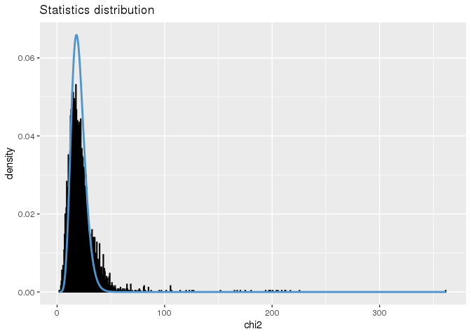

```
library(qvalue)
qval <-qvalue(x$pvalues)$qvalues
alpha <- 0.05
outliers <- which(qval < alpha)
length(outliers)

## [1] 272

outliers

##   [1]   64   66   67   84  102  103  104  120  139  140  162  175  202  217
##  [15]  219  220  251  252  253  258  262  272  275  281  293  294  295  316
##  [29]  359  432  492  512  537  538  539  540  616  617  649  675  676  689
##  [43]  690  720  724  793  794  834  895  949  978  992  993  997 1013 1021
##  [57] 1022 1023 1057 1086 1110 1111 1154 1170 1180 1181 1182 1183 1189 1228
##  [71] 1232 1233 1234 1235 1242 1243 1268 1269 1280 1281 1339 1351 1369 1381
##  [85] 1429 1430 1455 1497 1556 1575 1576 1605 1625 1632 1641 1675 1676 1753
##  [99] 1768 1771 1787 1799 1829 1946 1950 1951 1972 1991 2005 2015 2024 2033
## [113] 2123 2146 2171 2192 2255 2260 2317 2318 2319 2352 2354 2364 2365 2391
## [127] 2428 2430 2442 2443 2444 2445 2485 2486 2522 2527 2529 2530 2531 2532
## [141] 2533 2550 2667 2719 2725 2726 2727 2744 2784 2793 2839 2924 2949 2950
## [155] 2979 3022 3047 3169 3249 3265 3266 3267 3328 3383 3472 3473 3492 3536
## [169] 3537 3539 3576 3577 3578 3650 3651 3664 3680 3696 3708 3713 3740 3741
## [183] 3742 3764 3765 3779 3799 3800 3803 3902 3955 3958 3959 3979 3981 3982
## [197] 3983 3984 3985 3987 4014 4015 4035 4037 4038 4039 4040 4046 4065 4084
## [211] 4087 4098 4125 4140 4141 4142 4143 4144 4171 4216 4220 4233 4234 4235
## [225] 4264 4265 4274 4285 4298 4302 4303 4326 4346 4347 4370 4373 4383 4386
## [239] 4414 4416 4420 4421 4422 4423 4539 4718 4725 4726 4740 4767 4768 4769
## [253] 4770 4815 4836 4872 4880 4881 4882 4883 4884 4885 4886 4908 4916 4985
## [267] 4986 4987 4988 5018 5022 5023

hist(x$pvalues, xlab = "p-values", main = NULL, breaks = 50, col = "orange")
```

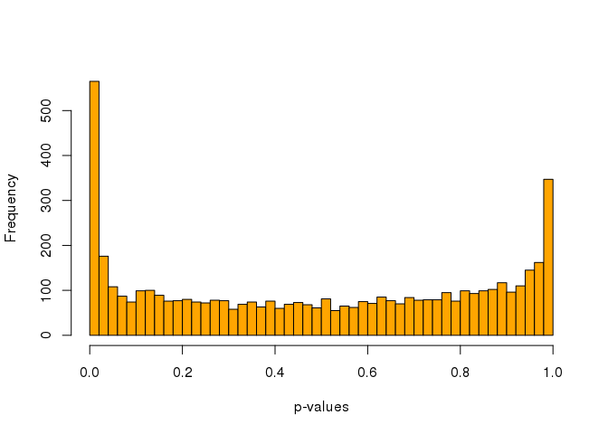

## First, we write the oulier to a text file

```
write.table(outliers, file ="outliers.txt", row.names = FALSE, col.names = FALSE)
```

## Next, we make a file with all the loci in the vcf but ignoring the headers and extracting only the 1st and second columnd that have the CHROM and ID labels. Additionally we add a column of numbers to every loci.

```
paste <(seq 1 5030) <(mawk '!/#/' SNP.DP3g95p5maf05.HWE_2A.recode.vcf | cut -f1,2) > SNP.DP3g95p5maf05.HWE_2A.loci
```

## We now compare the files outliers.txt and SNP.DP3g95p5maf05.HWE_2A.loci to have only those commun loci in each loci position and extract the fields 2 and 3 to make a new file that we will use to filter the vcf file.

## Note that these loci are not the ones that really correspond to those detected by PCAdapt becuase these many variants were discarded by it. I`m showing a way to get rid of those loci assuming they were the ones that really corresponded to the vcf.

## Helpful link: https://askubuntu.com/questions/879754/awk-comparing-2-columns-of-2-files-and-print-common-lines

```
awk 'FNR==NR{a[$1];next}($1 in a){print}' outliers.txt SNP.DP3g95p5maf05.HWE_2A.loci |cut -f2,3 > PCAadapt_outlier_loci
```

## Now we can continue to remove those outlier loci from the vcf using vcftools

```
vcftools --vcf SNP.DP3g95p5maf05.HWE_2A.recode.vcf --exclude-positions PCAadapt_outlier_loci  --recode --recode-INFO-all --out SNP.DP3g95p5maf05.HWE_2A_Neutral_PCA
Outputting VCF file...
After filtering, kept 4758 out of a possible 5030 Sites
Run Time = 5.00 seconds
```

## We can now run population analysis with a vcf supposedly composed of only neutral loci (detected by PCAdapt).Ideally, I meant to detect loci outlier loci through BayesScan and PCAdapt. Just bear in mind that multiple approaches to detect those putatively adaptive loci are needed to conduct population genomic analysis.

## We start by loading the following R packages

```
library(adegenet)


##
##    /// adegenet 2.1.1 is loaded ////////////
##
##    > overview: '?adegenet'
##    > tutorials/doc/questions: 'adegenetWeb()'
##    > bug reports/feature requests: adegenetIssues()

library(vcfR)
```

## We load our last vcf to a vcfR object and then to a genind object

```
my_vcf <- read.vcfR("SNP.DP3g95p5maf05.HWE_2A_Neutral_PCA.recode.vcf")

## Scanning file to determine attributes.
## File attributes:
##   meta lines: 65
##   header_line: 66
##   variant count: 4758
##   column count: 104
##
Meta line 65 read in.
## All meta lines processed.
## gt matrix initialized.
## Character matrix gt created.
##   Character matrix gt rows: 4758
##   Character matrix gt cols: 104
##   skip: 0
##   nrows: 4758
##   row_num: 0
##
Processed variant 1000
Processed variant 2000
Processed variant 3000
Processed variant 4000
Processed variant: 4758
## All variants processed

my_genind <- vcfR2genind(my_vcf)

## Warning in adegenet::df2genind(t(x), sep = sep, ...): entirely non-type
## marker(s) deleted
```

## We load a population table

```
CU_PAN_PR_pop<- read.table("/home/mgomez/repos/Orbicella/Orbicella_VCF/CU_PAN_PR_pop.txt",sep = "\t", header=TRUE)
colnames(my_vcf@gt)[-1] == CU_PAN_PR_pop$Sample

##  [1] TRUE TRUE TRUE TRUE TRUE TRUE TRUE TRUE TRUE TRUE TRUE TRUE TRUE TRUE
## [15] TRUE TRUE TRUE TRUE TRUE TRUE TRUE TRUE TRUE TRUE TRUE TRUE TRUE TRUE
## [29] TRUE TRUE TRUE TRUE TRUE TRUE TRUE TRUE TRUE TRUE TRUE TRUE TRUE TRUE
## [43] TRUE TRUE TRUE TRUE TRUE TRUE TRUE TRUE TRUE TRUE TRUE TRUE TRUE TRUE
## [57] TRUE TRUE TRUE TRUE TRUE TRUE TRUE TRUE TRUE TRUE TRUE TRUE TRUE TRUE
## [71] TRUE TRUE TRUE TRUE TRUE TRUE TRUE TRUE TRUE TRUE TRUE TRUE TRUE TRUE
## [85] TRUE TRUE TRUE TRUE TRUE TRUE TRUE TRUE TRUE TRUE TRUE

pop(my_genind) <- CU_PAN_PR_pop$Population
```

## Most code, if not all, taken from: ##https://grunwaldlab.github.io/Population_Genetics_in_R/gbs_analysis.html

## PCA

## A principal components analysis (PCA) converts the observed SNP data into a set of values of linearly

## uncorrelated variables called principal components that summarize the variation between samples.

## We can perform a PCA on our genlight object by using the glPCA function.

[output not shown]

[output cut: 168 more lines]

```
toRemove <- is.na(glMean(Orbicella_genlight, alleleAsUnit = FALSE))
which(toRemove) # position of entirely non-typed loci

## MZGG01000242.1_291794 MZGG01000242.1_291795 MZGG01000706.1_182800
##                   603                   604                  1891
## MZGG01001031.1_765514 MZGG01001031.1_765515
##                  2739                  2740

Orbicella_removed<- Orbicella_genlight[, !toRemove]


Orbicella_genlight_pca <- glPca(Orbicella_removed, nf =3)
barplot(Orbicella_genlight_pca$eig, col = heat.colors(50), main="PCA Eigenvalues")
title(ylab="Proportion of variance explained")
title(xlab="Eigenvalue")
```

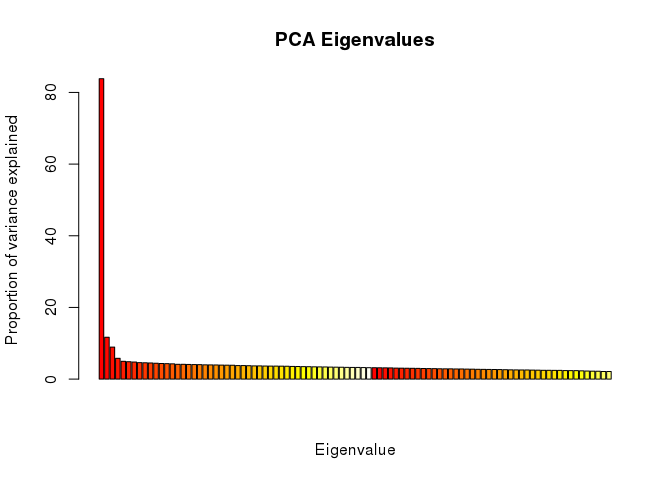

```
Orbicella_genlight_pca$eig

##  [1] 83.827183 11.672083  8.923728  5.805061  4.953858  4.850429  4.760571
##  [8]  4.596583  4.547211  4.493509  4.424089  4.355715  4.309513  4.248716
## [15]  4.124039  4.119655  4.083380  4.054665  4.034561  3.977311  3.957560
## [22]  3.937590  3.899993  3.880180  3.872024  3.777111  3.766872  3.742642
## [29]  3.686649  3.673822  3.647089  3.621577  3.615373  3.603631  3.577638
## [36]  3.537425  3.506709  3.466393  3.454585  3.418698  3.398791  3.379906
## [43]  3.346685  3.324143  3.305335  3.277415  3.255331  3.251797  3.205848
## [50]  3.182227  3.167938  3.155404  3.137988  3.123811  3.064686  3.053294
## [57]  3.026177  3.015045  2.981283  2.943395  2.933401  2.916103  2.873082
## [64]  2.863680  2.855141  2.829091  2.816734  2.790510  2.766366  2.726359
## [71]  2.717607  2.690379  2.665713  2.650429  2.616459  2.579968  2.555902
## [78]  2.544716  2.541851  2.511302  2.494388  2.456384  2.452621  2.438044
## [85]  2.422143  2.380212  2.365991  2.353271  2.296741  2.254812  2.206873
## [92]  2.187584  2.119224  2.105803

summary(Orbicella_genlight_pca)

##          Length Class  Mode
## eig         94  -none- numeric
## scores     285  -none- numeric
## loadings 14259  -none- numeric
## call         3  -none- call
```

# To view the results of the PCA we can use the package ggplot2. We need to convert the data frame

# that contains the principal components (Orbicella_genlight_pca$scores) into the new object Orbicella_genlight_pca_scores. In

# addition, we will add the population values as a new column in our Orbicella_genlight_pca_scores object, in order to be able to color samples by population.

# ggplot2 will plot the PCA, color the samples by population, and create ellipses that include 95%

# of the data for each the population:

```
Orbicella_genlight_pca_scores <- as.data.frame(Orbicella_genlight_pca$scores)
Orbicella_genlight_pca_scores$Population<- pop(Orbicella_removed)

set.seed(9)
p <- ggplot(Orbicella_genlight_pca_scores, aes(x=PC1, y=PC2, colour=Population))
p <- p + geom_point(size=2)
p <- p + stat_ellipse(level = 0.95, size = 1)
p <- p + scale_color_manual(values = cols)
p <- p + geom_hline(yintercept = 0)
p <- p + geom_vline(xintercept = 0)
theme<-theme(panel.background = element_blank(),panel.border=element_rect(fill=NA),panel.grid.major =
               element_blank(),panel.grid.minor = element_blank(),strip.background=element_blank(),
             axis.text.x=element_text(colour="black"),axis.text.y=element_text(colour="black"),
             axis.ticks=element_line(colour="black"),plot.margin=unit(c(1,1,1,1),"line"))
p <- p +theme
p

## Too few points to calculate an ellipse

## Warning in MASS::cov.trob(data[, vars]): Probable convergence failure

## Warning: Removed 1 rows containing missing values (geom_path).
```

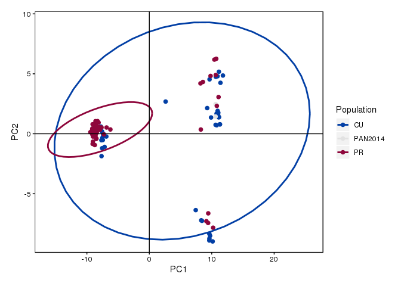

## We can further explore population assignments using a discriminant analysis of principal components (DAPC).

```
Orbicella_dapc <- dapc(Orbicella_removed, n.pca = 3, n.da = 3)

scatter(Orbicella_dapc, col = cols, cex = 2, legend = TRUE, clabel = F, posi.leg = "topleft", scree.pca = TRUE,
        posi.pca = "topright", cleg = 0.75)
```

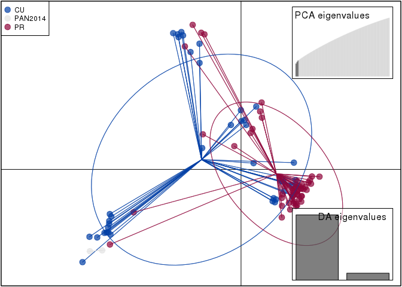

```
scatter(Orbicella_dapc, col = cols, cex = 2, legend = TRUE, clabel = F, posi.leg = "topleft", scree.pca = FALSE,
        posi.pca = "topleft", cleg = 0.75)
```

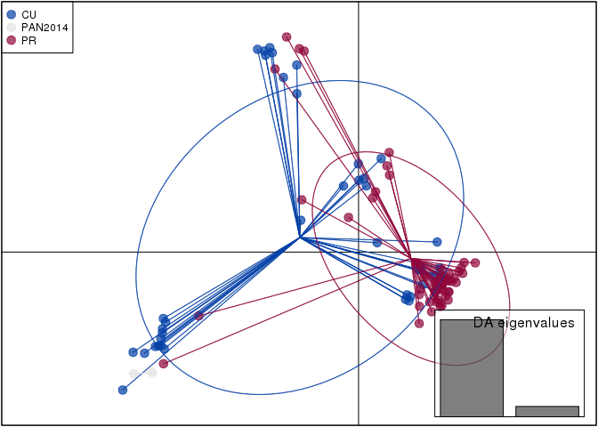

## Structure-like plot

```
compoplot(Orbicella_dapc,col = cols, posi = 'top')
```

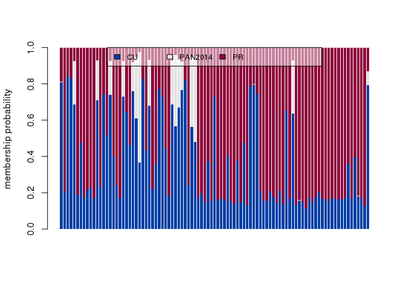

```
Orbicella_dapc_resu<- as.data.frame(Orbicella_dapc$posterior)
Orbicella_dapc_resu$pop <- pop(Orbicella_removed)
Orbicella_dapc_resu$indNames <- rownames(Orbicella_dapc_resu)
library(reshape2)
Orbicella_dapc_resu <- melt(Orbicella_dapc_resu)


colnames(Orbicella_dapc_resu) <- c("Original_Pop","Sample","Assigned_Pop","Posterior_membership_probability")

p <- ggplot(Orbicella_dapc_resu, aes(x=Sample, y=Posterior_membership_probability, fill=Assigned_Pop))
p <- p + geom_bar(stat='identity')
p <- p + scale_fill_manual(values = cols)
p <- p + facet_grid(~Original_Pop, scales = "free")
p <- p + theme(axis.text.x = element_text(angle = 90, hjust = 1, size = 8))
p
```

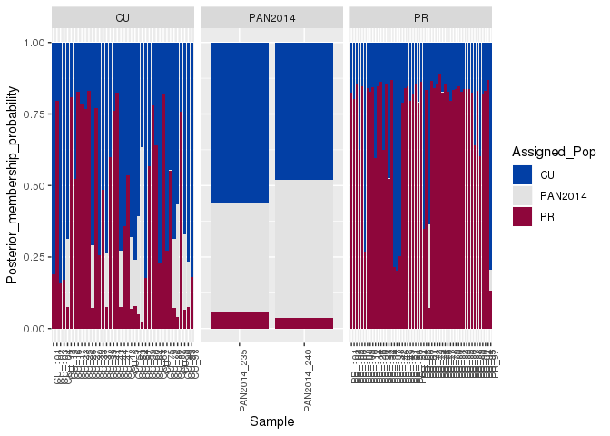

# We now calculate the genetic differentiation as measured the Fst statistics

```
##install.packages("hierfstat")
library(hierfstat)

##

Orbicella_fst <- genet.dist(my_genind,method="Fst")

Orbicella_fst

##            1          2
## 2 0.17246869
## 3 0.06543374 0.26767624

pop(my_genind)

##  [1] CU      CU      CU      CU      CU      CU      CU      CU
##  [9] CU      CU      CU      CU      CU      CU      CU      CU
## [17] CU      CU      CU      CU      CU      CU      CU      CU
## [25] CU      CU      CU      CU      CU      CU      CU      CU
## [33] CU      CU      CU      CU      CU      CU      CU      CU
## [41] PAN2014 PAN2014 PR      PR      PR      PR      PR      PR
## [49] PR      PR      PR      PR      PR      PR      PR      PR
## [57] PR      PR      PR      PR      PR      PR      PR      PR
## [65] PR      PR      PR      PR      PR      PR      PR      PR
## [73] PR      PR      PR      PR      PR      PR      PR      PR
## [81] PR      PR      PR      PR      PR      PR      PR      PR
## [89] PR      PR      PR      PR      PR      PR      PR
## Levels: CU PAN2014 PR
```

[output not shown]

Table 1. Genetic differentiation (*Fst*) of *Orbicella faveolata* populations across the Caribbean.

# Mantel test: isolation by distance

```
xy <-read.table("/home/mgomez/repos/Orbicella/Orbicella_VCF/dis_mat.txt",sep = "\t", header=TRUE)

## Warning in read.table("/home/mgomez/repos/Orbicella/Orbicella_VCF/
## dis_mat.txt", : incomplete final line found by readTableHeader on '/home/
## mgomez/repos/Orbicella/Orbicella_VCF/dis_mat.txt'

xy

##   Population      x       y
## 1         CU 374626 7545908
## 2    PAN2014 500000 9104828
## 3         PR 363881 7323166

my_genind@other$xy <- xy
toto <- genind2genpop(my_genind)

##
##  Converting data from a genind to a genpop object...
##
## ...done.

Dgeo <- dist(my_genind$other$xy)

## Warning in dist(my_genind$other$xy): NAs introduced by coercion

Dgen <- dist.genpop (toto,method=2)
ibd <- mantel.randtest(Dgen,Dgeo)
ibd

## Monte-Carlo test
## Call: mantel.randtest(m1 = Dgen, m2 = Dgeo)
##
## Observation: 0.9813359
##
## Based on 999 replicates
## Simulated p-value: 0.162
## Alternative hypothesis: greater
##
##     Std.Obs Expectation    Variance
##  1.39884017 -0.01281618  0.50509084

plot (ibd)
```

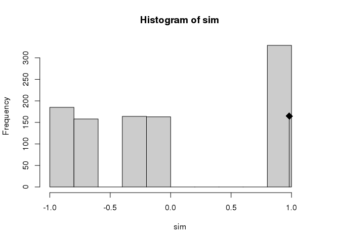

```
plot(Dgeo,Dgen)
abline(lm(Dgen~Dgeo), col="red", lty=2)
```

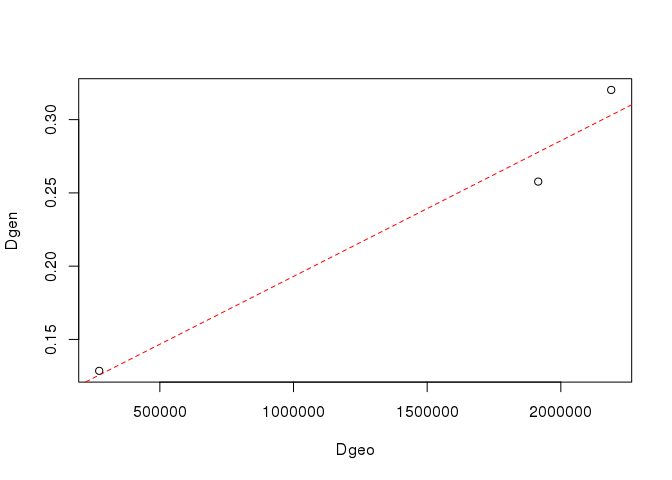